# Large Lat/Lon Plots and Filtering QC

Libraries

```r
library(tidyverse)
library(sf)
library(magrittr)
library(here)
```

Import Data

```r
catch <- read_csv(here("data", "Shelf_Flatfish_Haul_Catch.csv"), guess_max = 10000)
len <- read_csv(here("data","Shelf_Flatfish_Haul_Catch_Length.csv"), guess_max = 10000)
newdata <- read_csv(here("data", "Shelf_Flatfish_Haul_Specimen.csv"), guess_max = 10000)
spec <- read_csv(here("data", "Shelf_Flatfish_Haul_Specimen.csv"), guess_max = 10000)
station_info <- readRDS(here("data", "intermediates/station_info.rds"))
```

Filters

```r
catch <- catch %>%
  filter(CRUISE>= 199999 & CRUISE<201900,
         REGION=="BS") %>%#,
         #START_LATITUDE<65) %>%
  mutate(YEAR=floor((CRUISE/100)))

len <- len %>%
  filter(CRUISE>= 199999 & CRUISE<201900,
         REGION=="BS")%>%#,
         #START_LATITUDE<65) %>%
  mutate(YEAR=floor((CRUISE/100)))

newdata_bs <- newdata %>%
  filter(REGION=="BS") %>%
  # can use start time to get year, 9 characters total and it is last two
  mutate(YEAR=substr(START_TIME,8,9))
newdata_bs$YEAR %<>% factor()
summary(newdata_bs)
```

```
##     HAULJOIN          REGION             STRATUM      START_LATITUDE
##  Min.   : -19833   Length:30293       Min.   : 0.00   Min.   :54.66
##  1st Qu.: -12313   Class :character   1st Qu.:20.00   1st Qu.:56.66
##  Median :  -4828   Mode  :character   Median :31.00   Median :57.65
##  Mean   : 285701                      Mean   :34.68   Mean   :57.74
##  3rd Qu.: 858656                      3rd Qu.:50.00   3rd Qu.:58.69
##  Max.   :1195812                      Max.   :90.00   Max.   :64.67
##                                       NA's   :99
##   END_LATITUDE   START_LONGITUDE  END_LONGITUDE     STATIONID
##  Min.   :54.66   Min.   :-178.7   Min.   :-178.6   Length:30293
##  1st Qu.:56.67   1st Qu.:-171.6   1st Qu.:-171.6   Class :character
##  Median :57.66   Median :-167.6   Median :-167.6   Mode  :character
##  Mean   :57.84   Mean   :-167.9   Mean   :-167.8
##  3rd Qu.:58.99   3rd Qu.:-164.0   3rd Qu.:-164.0
##  Max.   :64.65   Max.   :-158.0   Max.   :-158.0
##  NA's   :2148                     NA's   :2148
##    GEAR_DEPTH      BOTTOM_DEPTH    BOTTOM_TYPE     SURFACE_TEMPERATURE
##  Min.   : 15.00   Min.   : 18.0   Min.   : 0.000   Min.   :-0.300
##  1st Qu.: 54.00   1st Qu.: 56.0   1st Qu.: 0.000   1st Qu.: 5.200
##  Median : 77.00   Median : 79.0   Median : 0.000   Median : 6.900
##  Mean   : 83.69   Mean   : 85.7   Mean   : 3.964   Mean   : 6.669
##  3rd Qu.:112.00   3rd Qu.:113.0   3rd Qu.: 0.000   3rd Qu.: 8.300
##  Max.   :476.00   Max.   :512.0   Max.   :54.000   Max.   :14.200
##  NA's   :86                       NA's   :25495    NA's   :920
##  GEAR_TEMPERATURE      GEAR        START_TIME          SPECIMENID
##  Min.   :-1.700   Min.   :20.00   Length:30293       Min.   :  0.0
##  1st Qu.: 1.700   1st Qu.:44.00   Class :character   1st Qu.: 59.0
##  Median : 3.000   Median :44.00   Mode  :character   Median :149.0
##  Mean   : 2.906   Mean   :42.04                      Mean   :169.6
##  3rd Qu.: 4.000   3rd Qu.:44.00                      3rd Qu.:258.0
##  Max.   :14.000   Max.   :44.00                      Max.   :640.0
##  NA's   :1161
##    BIOSTRATUM      SPECIES_CODE       LENGTH           SEX
##  Min.   : 0.000   Min.   :10130   Min.   : 40.0   Min.   :1.00
##  1st Qu.: 0.000   1st Qu.:10130   1st Qu.:210.0   1st Qu.:1.00
##  Median : 0.000   Median :10130   Median :290.0   Median :2.00
##  Mean   : 4.551   Mean   :10179   Mean   :284.2   Mean   :1.57
##  3rd Qu.: 0.000   3rd Qu.:10261   3rd Qu.:350.0   3rd Qu.:2.00
##  Max.   :99.000   Max.   :10261   Max.   :550.0   Max.   :3.00
##
##      WEIGHT            AGE              YEAR
##  Min.   :   1.0   Min.   : 0.000   19     : 1630
##  1st Qu.:  90.0   1st Qu.: 5.000   18     : 1376
##  Median : 240.0   Median : 8.000   09     : 1272
##  Mean   : 317.6   Mean   : 9.068   16     : 1240
##  3rd Qu.: 460.0   3rd Qu.:12.000   17     : 1213
##  Max.   :1978.0   Max.   :37.000   10     : 1210
##  NA's   :6146     NA's   :4956     (Other):22352
```

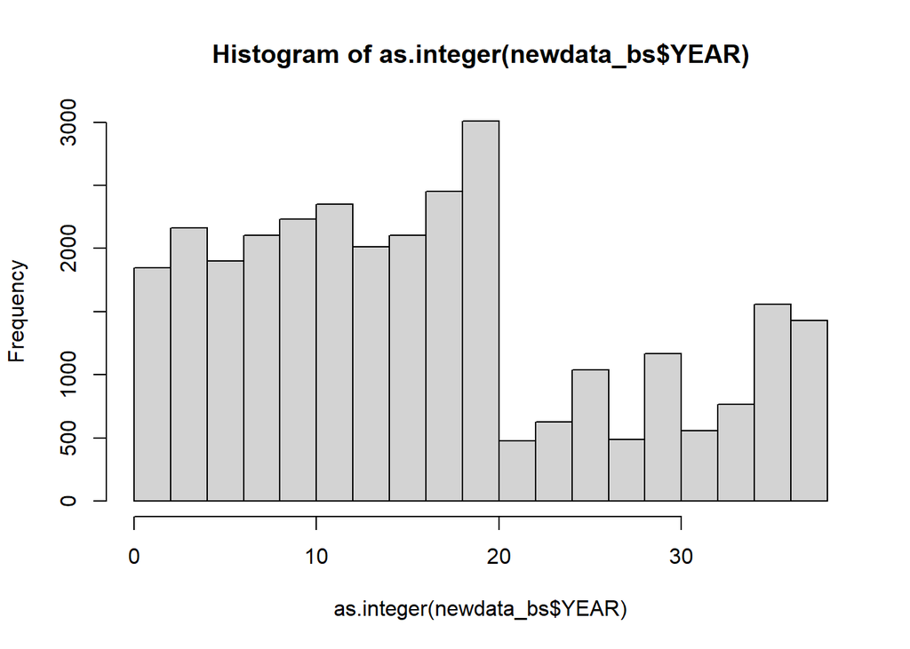

```r
hist(as.integer(newdata_bs$YEAR))
```

```r
# trying to separate out years so I can check that I won't lose anything by just using hauljoin from prior filtering on catch
unique(newdata_bs$YEAR)
```

```
##  [1] 05 06 07 08 09 10 11 12 13 14 15 16 17 18 19 82 84 71 72 76 74 75 73 92 81
## [26] 85 93 95 96 97 94 98 99 00 01 02 03 04
## 38 Levels: 00 01 02 03 04 05 06 07 08 09 10 11 12 13 14 15 16 17 18 19 ... 99
```

```r
newdata_bs_00 <- newdata_bs %>%
  filter(as.integer(YEAR)<20)

hauljoin_list <- unique(catch$HAULJOIN)
spec <- spec %>%
  filter(HAULJOIN %in% (hauljoin_list)) %>%
  mutate(YEAR=as.integer(substr(START_TIME,8,9)))
remove(hauljoin_list)
```

```r
summary(newdata)
```

```
##     HAULJOIN          REGION             STRATUM       START_LATITUDE
##  Min.   : -19833   Length:65833       Min.   :  0.00   Min.   :51.20
##  1st Qu.: -10490   Class :character   1st Qu.: 12.00   1st Qu.:55.65
##  Median :  10657   Mode  :character   Median : 31.00   Median :57.02
##  Mean   : 275896                      Mean   : 87.76   Mean   :56.87
##  3rd Qu.: 802749                      3rd Qu.: 70.00   3rd Qu.:58.33
##  Max.   :1218509                      Max.   :793.00   Max.   :64.67
##                                       NA's   :4496
##   END_LATITUDE   START_LONGITUDE  END_LONGITUDE     STATIONID
##  Min.   :51.19   Min.   :-180.0   Min.   :-180.0   Length:65833
##  1st Qu.:55.64   1st Qu.:-168.5   1st Qu.:-168.3   Class :character
##  Median :57.05   Median :-162.8   Median :-162.2   Mode  :character
##  Mean   :56.86   Mean   :-149.7   Mean   :-149.1
##  3rd Qu.:58.34   3rd Qu.:-153.4   3rd Qu.:-153.5
##  Max.   :64.65   Max.   : 180.0   Max.   : 180.0
##  NA's   :2666                     NA's   :2666
##    GEAR_DEPTH     BOTTOM_DEPTH    BOTTOM_TYPE    SURFACE_TEMPERATURE
##  Min.   :  0.0   Min.   : 14.0   Min.   : 0.00   Min.   :-0.300
##  1st Qu.: 68.0   1st Qu.: 71.0   1st Qu.: 0.00   1st Qu.: 5.400
##  Median :100.0   Median :103.0   Median : 0.00   Median : 7.300
##  Mean   :108.5   Mean   :111.2   Mean   : 1.15   Mean   : 7.558
##  3rd Qu.:141.0   3rd Qu.:143.0   3rd Qu.: 0.00   3rd Qu.: 9.400
##  Max.   :476.0   Max.   :512.0   Max.   :54.00   Max.   :16.800
##  NA's   :181                     NA's   :43743   NA's   :3902
##  GEAR_TEMPERATURE      GEAR        START_TIME          SPECIMENID
##  Min.   :-1.700   Min.   : 20.0   Length:65833       Min.   :    0.0
##  1st Qu.: 2.900   1st Qu.: 44.0   Class :character   1st Qu.:   22.0
##  Median : 4.300   Median : 44.0   Mode  :character   Median :  137.0
##  Mean   : 4.109   Mean   :155.6                      Mean   :  293.2
##  3rd Qu.: 5.400   3rd Qu.:172.0                      3rd Qu.:  277.0
##  Max.   :14.000   Max.   :825.0                      Max.   :39076.0
##  NA's   :8513
##    BIOSTRATUM      SPECIES_CODE       LENGTH         SEX
##  Min.   :  0.00   Min.   :10130   Min.   : 30   Min.   :1.000
##  1st Qu.:  0.00   1st Qu.:10130   1st Qu.:240   1st Qu.:1.000
##  Median :  0.00   Median :10130   Median :300   Median :2.000
##  Mean   : 14.71   Mean   :10175   Mean   :296   Mean   :1.565
##  3rd Qu.:  0.00   3rd Qu.:10261   3rd Qu.:360   3rd Qu.:2.000
##  Max.   :722.00   Max.   :10261   Max.   :610   Max.   :3.000
##
##      WEIGHT            AGE
##  Min.   :   1.0   Min.   : 0.000
##  1st Qu.: 122.0   1st Qu.: 5.000
##  Median : 268.0   Median : 8.000
##  Mean   : 342.2   Mean   : 8.708
##  3rd Qu.: 474.0   3rd Qu.:12.000
##  Max.   :7500.0   Max.   :37.000
##  NA's   :11326    NA's   :24486
```

```r
# length(unique(newdata$STATIONID))
# unique(newdata$SPECIES_CODE) # only has fhs and nrs
# unique(newdata$REGION)
#
# ggplot()+
#   geom_point(data= newdata_test,aes(x=START_LONGITUDE, y=START_LATITUDE), alpha=0.1)+
#   coord_cartesian(xlim=c(-200, -100))+
#   geom_point(data= newdata1,aes(x=START_LONGITUDE, y=START_LATITUDE), alpha=0.1, color="red")
# ggplot()+
#   geom_point(data= newdata_bs_00,aes(x=START_LONGITUDE, y=START_LATITUDE), alpha=0.1)#+
#   #coord_cartesian(xlim=c(-200, -100))
```

End of sanity check that my filters from before are correct and I can just use hauljoin to filter out newdata.

Understanding which data has which variables

```r
c <- names(catch)
l <- names(len)
s <- names(spec)
l %in% c
```

```
##  [1]  TRUE  TRUE  TRUE  TRUE  TRUE  TRUE  TRUE  TRUE  TRUE  TRUE  TRUE  TRUE
## [13]  TRUE  TRUE  TRUE  TRUE  TRUE  TRUE  TRUE  TRUE  TRUE  TRUE  TRUE  TRUE
## [25]  TRUE  TRUE  TRUE FALSE FALSE FALSE  TRUE  TRUE  TRUE
```

```r
l # length frequency and sex are the only additional variables that len has over catch. Catch is redundant but useful to just look at variables over time.
```

```
##  [1] "HAULJOIN"            "REGION"              "VESSEL"
##  [4] "CRUISE"              "HAUL"                "PERFORMANCE"
##  [7] "START_TIME"          "DURATION"            "DISTANCE_FISHED"
## [10] "NET_WIDTH"           "NET_MEASURED"        "NET_HEIGHT"
## [13] "STRATUM"             "START_LATITUDE"      "END_LATITUDE"
## [16] "START_LONGITUDE"     "END_LONGITUDE"       "STATIONID"
## [19] "GEAR_DEPTH"          "BOTTOM_DEPTH"        "BOTTOM_TYPE"
## [22] "SURFACE_TEMPERATURE" "GEAR_TEMPERATURE"    "WIRE_LENGTH"
## [25] "GEAR"                "ABUNDANCE_HAUL"      "SPECIES_CODE"
## [28] "LENGTH"              "FREQUENCY"           "SEX"
## [31] "CATCH_WEIGHT"        "CATCH_NUMBER_FISH"   "YEAR"
```

```r
s %in% c # there are a lot of differences between spec and the other two, which makes sense
```

```
##  [1]  TRUE  TRUE  TRUE  TRUE  TRUE  TRUE  TRUE  TRUE  TRUE  TRUE  TRUE  TRUE
## [13]  TRUE  TRUE  TRUE FALSE FALSE  TRUE FALSE FALSE FALSE FALSE  TRUE
```

```r
s #has age, weight
```

```
##  [1] "HAULJOIN"            "REGION"              "STRATUM"
##  [4] "START_LATITUDE"      "END_LATITUDE"        "START_LONGITUDE"
##  [7] "END_LONGITUDE"       "STATIONID"           "GEAR_DEPTH"
## [10] "BOTTOM_DEPTH"        "BOTTOM_TYPE"         "SURFACE_TEMPERATURE"
## [13] "GEAR_TEMPERATURE"    "GEAR"                "START_TIME"
## [16] "SPECIMENID"          "BIOSTRATUM"          "SPECIES_CODE"
## [19] "LENGTH"              "SEX"                 "WEIGHT"
## [22] "AGE"                 "YEAR"
```

```r
# i'm carrying around a lot of variables. They mightbe nice to look at later but atm they're distracting. Next plan is to cut them out (i.e. gear, etc)
c
```

```
##  [1] "HAULJOIN"            "REGION"              "VESSEL"
##  [4] "CRUISE"              "HAUL"                "PERFORMANCE"
##  [7] "START_TIME"          "DURATION"            "DISTANCE_FISHED"
## [10] "NET_WIDTH"           "NET_MEASURED"        "NET_HEIGHT"
## [13] "STRATUM"             "START_LATITUDE"      "END_LATITUDE"
## [16] "START_LONGITUDE"     "END_LONGITUDE"       "STATIONID"
## [19] "GEAR_DEPTH"          "BOTTOM_DEPTH"        "BOTTOM_TYPE"
## [22] "SURFACE_TEMPERATURE" "GEAR_TEMPERATURE"    "WIRE_LENGTH"
## [25] "GEAR"                "ABUNDANCE_HAUL"      "CATCH_WEIGHT"
## [28] "CATCH_NUMBER_FISH"   "SPECIES_CODE"        "YEAR"
```

```r
l
```

```
##  [1] "HAULJOIN"            "REGION"              "VESSEL"
##  [4] "CRUISE"              "HAUL"                "PERFORMANCE"
##  [7] "START_TIME"          "DURATION"            "DISTANCE_FISHED"
## [10] "NET_WIDTH"           "NET_MEASURED"        "NET_HEIGHT"
## [13] "STRATUM"             "START_LATITUDE"      "END_LATITUDE"
## [16] "START_LONGITUDE"     "END_LONGITUDE"       "STATIONID"
## [19] "GEAR_DEPTH"          "BOTTOM_DEPTH"        "BOTTOM_TYPE"
## [22] "SURFACE_TEMPERATURE" "GEAR_TEMPERATURE"    "WIRE_LENGTH"
## [25] "GEAR"                "ABUNDANCE_HAUL"      "SPECIES_CODE"
## [28] "LENGTH"              "FREQUENCY"           "SEX"
## [31] "CATCH_WEIGHT"        "CATCH_NUMBER_FISH"   "YEAR"
```

```r
s
```

```
##  [1] "HAULJOIN"            "REGION"              "STRATUM"
##  [4] "START_LATITUDE"      "END_LATITUDE"        "START_LONGITUDE"
##  [7] "END_LONGITUDE"       "STATIONID"           "GEAR_DEPTH"
## [10] "BOTTOM_DEPTH"        "BOTTOM_TYPE"         "SURFACE_TEMPERATURE"
## [13] "GEAR_TEMPERATURE"    "GEAR"                "START_TIME"
## [16] "SPECIMENID"          "BIOSTRATUM"          "SPECIES_CODE"
## [19] "LENGTH"              "SEX"                 "WEIGHT"
## [22] "AGE"                 "YEAR"
```

Spatial subsetting code from making grid

```r
len_e <- len %>%
  filter(CRUISE>= 199999 & CRUISE<201900,
         REGION=="BS")%>%#,
         #START_LATITUDE<65) %>%
  mutate(YEAR=floor((CRUISE/100))) %>%
  group_by(HAULJOIN,SPECIES_CODE) %>%
  mutate(n_SUBSAMP = sum(FREQUENCY))%>%
  group_by(HAULJOIN,SPECIES_CODE, LENGTH) %>%
  mutate(SS_PROPORTION=(FREQUENCY/n_SUBSAMP),
         n_HAUL = (SS_PROPORTION*CATCH_NUMBER_FISH))
```

Not sure the following is useful

```r
# by_len_stat_yr_sx <- len_haul_expanded %>%
#   group_by(STATIONID,SPECIES_CODE, SEX, YEAR) %>%
#   mutate(n_SPEC_STATION = sum(FREQUENCY))%>%
#   group_by(STATIONID,SPECIES_CODE, LENGTH, SEX, YEAR) %>%
#   mutate(HAUL_S_PROPORTION=(FREQUENCY/n_SPEC_STATION),
#          n_STATION = (HAUL_S_PROPORTION*CATCH_NUMBER_FISH))%>%
#   #group_by(STATIONID, SPECIES_CODE,LENGTH, SEX,YEAR) %>%
#   #summarise(PER_STAT_YEAR =sum(n_STATION))
```

Plot surface temp at locations each year

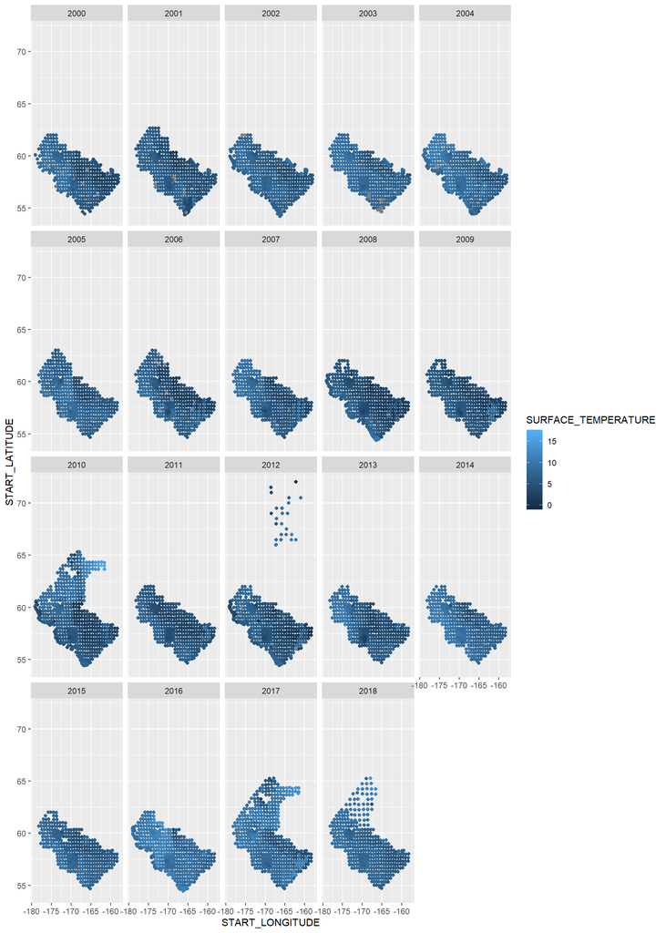

```r
ggplot(catch)+
  geom_point(aes(x=START_LONGITUDE, y=START_LATITUDE, color=SURFACE_TEMPERATURE))+
  facet_wrap(~YEAR)
```

Give stations average latitudes and longitudes

```r
catch <- catch %>%
  mutate(AVG_LON = (START_LONGITUDE+END_LONGITUDE)/2,
         AVG_LAT = (START_LATITUDE+END_LATITUDE)/2)
# Add average lat and lon by STATIONID to catch
STATION_AVG_LAT<-tapply(catch$AVG_LAT,catch$STATIONID,mean)
STATION_AVG_LON<-tapply(catch$AVG_LON,catch$STATIONID,mean)
index<-match(catch$STATIONID,names(STATION_AVG_LON))
catch$STATION_AVG_LON<-STATION_AVG_LON[index]
catch$STATION_AVG_LAT<-STATION_AVG_LAT[index]
```

Testing

```r
testa <- catch %>% filter(STATIONID=="K-20")
length(unique(catch$STATION_AVG_LON))
```

```
## [1] 1016
```

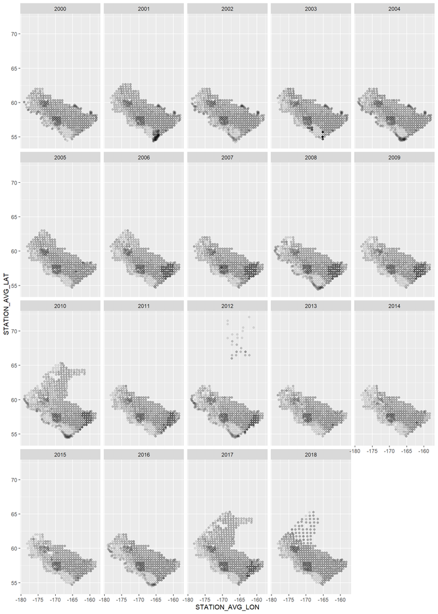

```r
#NICE
ggplot(data=catch) +
  geom_point(aes(x=STATION_AVG_LON, y=STATION_AVG_LAT),
             alpha=0.1)+
  facet_wrap(~YEAR)
```

Continue to other dfs

```r
index<-match(len_e$STATIONID,names(STATION_AVG_LON))
len_e$STATION_AVG_LON<-STATION_AVG_LON[index]
len_e$STATION_AVG_LAT<-STATION_AVG_LAT[index]

index<-match(spec$STATIONID,names(STATION_AVG_LON))
spec$STATION_AVG_LON<-STATION_AVG_LON[index]
spec$STATION_AVG_LAT<-STATION_AVG_LAT[index]
```

Goals: 1. make a grid based on yearly avg values at each station for envirmtal var 2. bin the environmental variable by something reasonable 3. intersect this shapefile/grid with my expanded length data set 4. average across each envtal variable area

Note that Bering Sea crs is 3571 DID NOT WORK

```r
# catch_sf <- st_as_sf(catch, coords=c("STATION_AVG_LON", "STATION_AVG_LAT"), crs=3571)
# grid <- st_make_grid(catch_sf, n=c(32,32), what="polygons")
```

Plot it

```r
# ggplot()+
#   geom_sf(data=grid)+
#   geom_point(data=catch, aes(x=START_LONGITUDE, y=START_LATITUDE), color="blue", alpha=0.1)+
#   theme_minimal()+
#   theme(axis.text.y=element_blank())
```

Stopping using sf I’m gonna make an index of depths bc they shouldn’t change

```r
catch <- catch %>%
  group_by(STATIONID) %>%
  mutate(AVG_DEPTH = mean(BOTTOM_DEPTH))
# Add average depth by STATIONID to catch
STATION_AVG_DEPTH<-tapply(catch$AVG_DEPTH,catch$STATIONID,mean) #OOPS
index<-match(catch$STATIONID,names(STATION_AVG_DEPTH))
catch$STATION_AVG_DEPTH<-STATION_AVG_DEPTH[index]
names(catch)
```

```
##  [1] "HAULJOIN"            "REGION"              "VESSEL"
##  [4] "CRUISE"              "HAUL"                "PERFORMANCE"
##  [7] "START_TIME"          "DURATION"            "DISTANCE_FISHED"
## [10] "NET_WIDTH"           "NET_MEASURED"        "NET_HEIGHT"
## [13] "STRATUM"             "START_LATITUDE"      "END_LATITUDE"
## [16] "START_LONGITUDE"     "END_LONGITUDE"       "STATIONID"
## [19] "GEAR_DEPTH"          "BOTTOM_DEPTH"        "BOTTOM_TYPE"
## [22] "SURFACE_TEMPERATURE" "GEAR_TEMPERATURE"    "WIRE_LENGTH"
## [25] "GEAR"                "ABUNDANCE_HAUL"      "CATCH_WEIGHT"
## [28] "CATCH_NUMBER_FISH"   "SPECIES_CODE"        "YEAR"
## [31] "AVG_LON"             "AVG_LAT"             "STATION_AVG_LON"
## [34] "STATION_AVG_LAT"     "AVG_DEPTH"           "STATION_AVG_DEPTH"
```

```r
nums <- c(18,33,34,36)
station_deets <- catch[,nums]
station_info <- distinct(station_deets)
length(unique(catch$STATIONID))
```

```
## [1] 1016
```

plot check

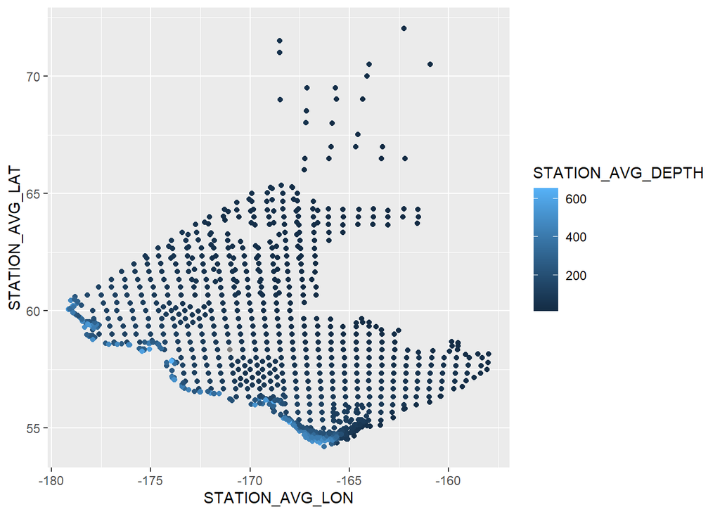

```r
ggplot(station_info)+
  geom_point(aes(x = STATION_AVG_LON, y=STATION_AVG_LAT, color=STATION_AVG_DEPTH))
```

lose NAs

```r
station_info <- na.omit(station_info)
```

Check out medians

```r
summary(len_e)
```

```
##     HAULJOIN          REGION              VESSEL          CRUISE
##  Min.   : -18223   Length:498019      Min.   : 57.0   Min.   :200001
##  1st Qu.: -13584   Class :character   1st Qu.: 88.0   1st Qu.:200401
##  Median :  -7153   Mode  :character   Median : 89.0   Median :200801
##  Mean   : 297906                      Mean   :106.5   Mean   :200876
##  3rd Qu.:1010864                      3rd Qu.: 94.0   3rd Qu.:201301
##  Max.   :1350426                      Max.   :178.0   Max.   :201801
##
##       HAUL         PERFORMANCE       START_TIME           DURATION
##  Min.   :  1.00   Min.   :-6.0000   Length:498019      Min.   :0.0510
##  1st Qu.: 37.00   1st Qu.: 0.0000   Class :character   1st Qu.:0.5000
##  Median : 80.00   Median : 0.0000   Mode  :character   Median :0.5110
##  Mean   : 87.81   Mean   : 0.1356                      Mean   :0.5035
##  3rd Qu.:129.00   3rd Qu.: 0.0000                      3rd Qu.:0.5210
##  Max.   :501.00   Max.   : 7.0000                      Max.   :0.7880
##
##  DISTANCE_FISHED   NET_WIDTH      NET_MEASURED         NET_HEIGHT
##  Min.   :0.118   Min.   : 2.257   Length:498019      Min.   :0.000
##  1st Qu.:2.748   1st Qu.:15.783   Class :character   1st Qu.:2.116
##  Median :2.824   Median :16.580   Mode  :character   Median :2.314
##  Mean   :2.770   Mean   :16.585                      Mean   :2.493
##  3rd Qu.:2.895   3rd Qu.:17.367                      3rd Qu.:2.618
##  Max.   :4.200   Max.   :21.530                      Max.   :9.242
##                                                      NA's   :10085
##     STRATUM      START_LATITUDE   END_LATITUDE   START_LONGITUDE
##  Min.   : 1.00   Min.   :54.20   Min.   :54.20   Min.   :-179.1
##  1st Qu.:20.00   1st Qu.:57.00   1st Qu.:57.00   1st Qu.:-170.0
##  Median :31.00   Median :57.99   Median :57.99   Median :-166.8
##  Mean   :33.07   Mean   :58.13   Mean   :58.13   Mean   :-167.0
##  3rd Qu.:42.00   3rd Qu.:59.02   3rd Qu.:59.02   3rd Qu.:-163.4
##  Max.   :90.00   Max.   :72.03   Max.   :72.03   Max.   :-158.0
##  NA's   :8618
##  END_LONGITUDE     STATIONID           GEAR_DEPTH      BOTTOM_DEPTH
##  Min.   :-179.1   Length:498019      Min.   :  9.00   Min.   : 11.00
##  1st Qu.:-170.0   Class :character   1st Qu.: 44.00   1st Qu.: 46.00
##  Median :-166.8   Mode  :character   Median : 63.00   Median : 65.00
##  Mean   :-167.0                      Mean   : 71.82   Mean   : 74.28
##  3rd Qu.:-163.4                      3rd Qu.: 82.00   3rd Qu.: 84.00
##  Max.   :-158.0                      Max.   :651.00   Max.   :656.00
##                                      NA's   :1473     NA's   :1
```

[output cut: 25 more lines]

```
##  Min.   :2000   Min.   :   1   Min.   :0.0005767   Min.   :   0.991
##  1st Qu.:2004   1st Qu.:  61   1st Qu.:0.0136986   1st Qu.:   3.000
##  Median :2008   Median : 107   Median :0.0273973   Median :   8.348
##  Mean   :2009   Mean   : 118   Mean   :0.0472211   Mean   :  28.469
##  3rd Qu.:2013   3rd Qu.: 148   3rd Qu.:0.0526316   3rd Qu.:  26.016
##  Max.   :2018   Max.   :6391   Max.   :1.0000000   Max.   :6202.500
##
##  STATION_AVG_LON  STATION_AVG_LAT
##  Min.   :-179.1   Min.   :54.20
##  1st Qu.:-170.0   1st Qu.:57.00
##  Median :-166.8   Median :58.00
##  Mean   :-167.0   Mean   :58.14
##  3rd Qu.:-163.4   3rd Qu.:59.00
##  Max.   :-158.0   Max.   :72.03
##  NA's   :1286     NA's   :1286
```

Overall median by station

```r
# gets the median while accounting for the number of times that a length is repeated per haul
get_median <- function(leng, n_hau){
  new_list <- rep(leng, round(n_hau))
  return(median(new_list, na.rm = TRUE))
}
```

Making data for plots

```r
for_plot <- len_e %>%
  filter(SPECIES_CODE==10130) %>%
  group_by(STATIONID) %>% # maybe add SEX
  summarise(wt_med = get_median(LENGTH, n_HAUL))
for_plot1 <- na.omit(for_plot)
more_for_plot <- inner_join(for_plot1, station_info, by="STATIONID")
```

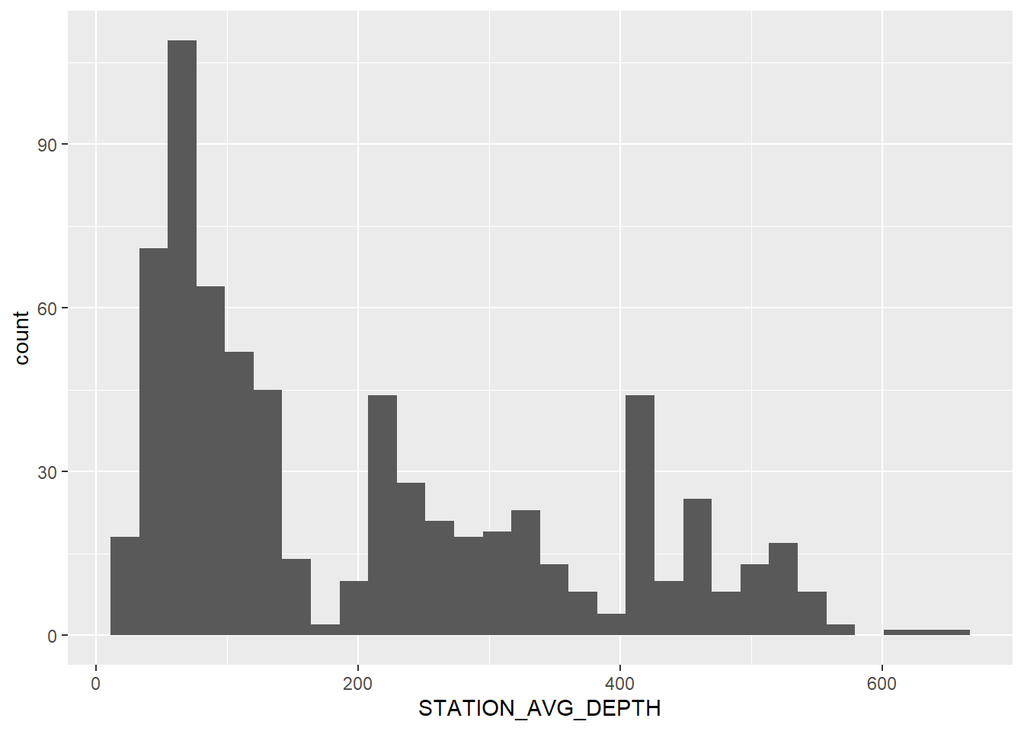

```r
ggplot(more_for_plot)+ geom_histogram(aes(x=STATION_AVG_DEPTH))
```

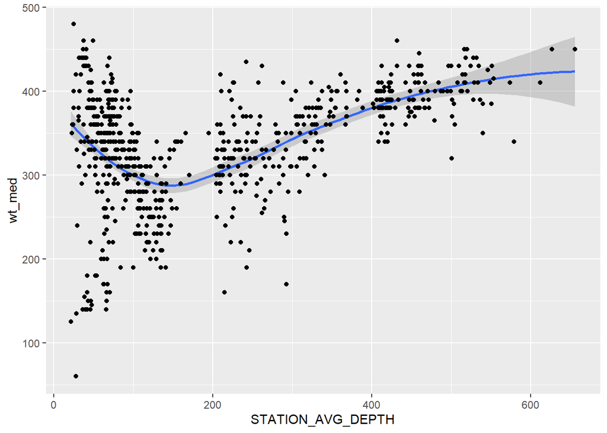

```r
ggplot(more_for_plot)+ geom_smooth(aes(x=STATION_AVG_DEPTH, y=wt_med))+
 geom_point(aes(x=STATION_AVG_DEPTH, y=wt_med))
```

```r
# gets the median while accounting for the number of times that a length is repeated per haul
get_median <- function(leng, n_hau){
  new_list <- rep(leng, round(n_hau))
  return(median(new_list, na.rm = TRUE))
}
```

Set up original `plot_dat`

```r
plot_dat <- len_e %>%
  filter(SPECIES_CODE==10130) %>%
  group_by(STATIONID, YEAR) %>%
  summarise(MED = get_median(LENGTH, n_HAUL))
plot_dat1 <- inner_join(plot_dat, station_info, by="STATIONID")
```

Plot of station depths

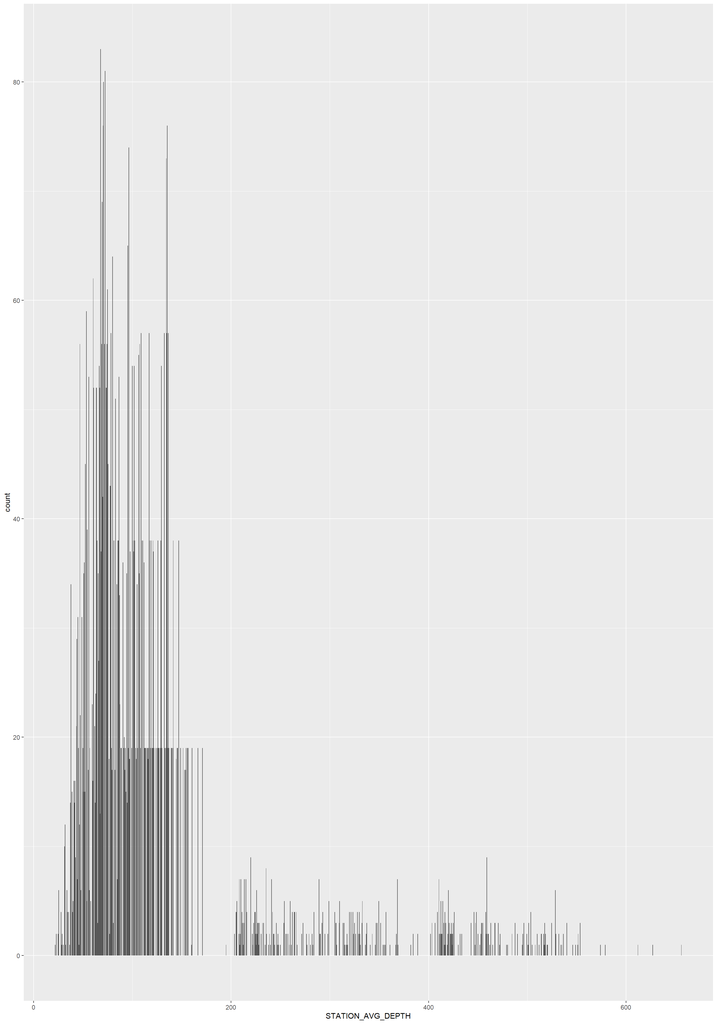

```r
ggplot(plot_dat1) +
  geom_histogram(binwidth=.5,aes(x=STATION_AVG_DEPTH))
```

Make depth bins

```r
summary(plot_dat1$STATION_AVG_DEPTH)
```

```
##    Min. 1st Qu.  Median    Mean 3rd Qu.    Max.
##   21.98   68.89   94.30  116.50  128.48  656.00
```

```r
depth_bin_cuts <- c(21.97,69.57, 92.85, 119.22,656.01)
plot_dat2 <- plot_dat1
plot_dat2$DEPTH_BINS <- cut(plot_dat2$STATION_AVG_DEPTH, depth_bin_cuts, include.lowest = TRUE)
```

Lat/Lon and median split by year and depth bin

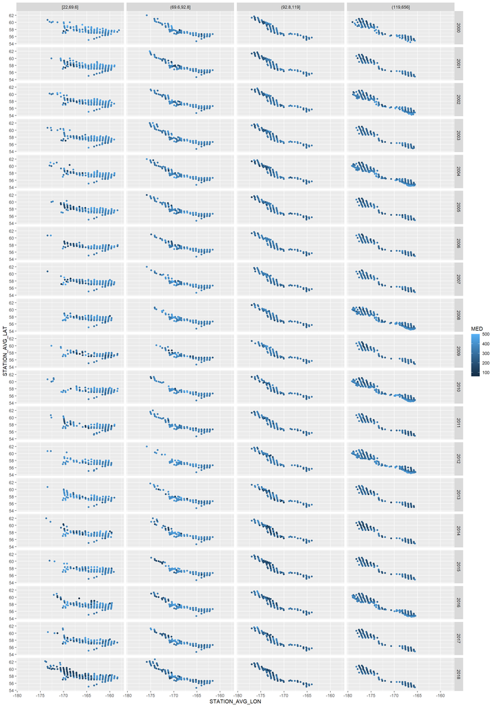

```r
ggplot(plot_dat2) +
  geom_point(aes(x=STATION_AVG_LON, y=STATION_AVG_LAT, color=MED)) +
  facet_grid(YEAR~DEPTH_BINS)
```

Making plots with `facet_grid()`

```r
plot_dat2 <- plot_dat1
plot_dat2$DEPTH_BINS <- cut(plot_dat2$STATION_AVG_DEPTH, 4, include.lowest = TRUE)
```

Plot medians years and depth bins

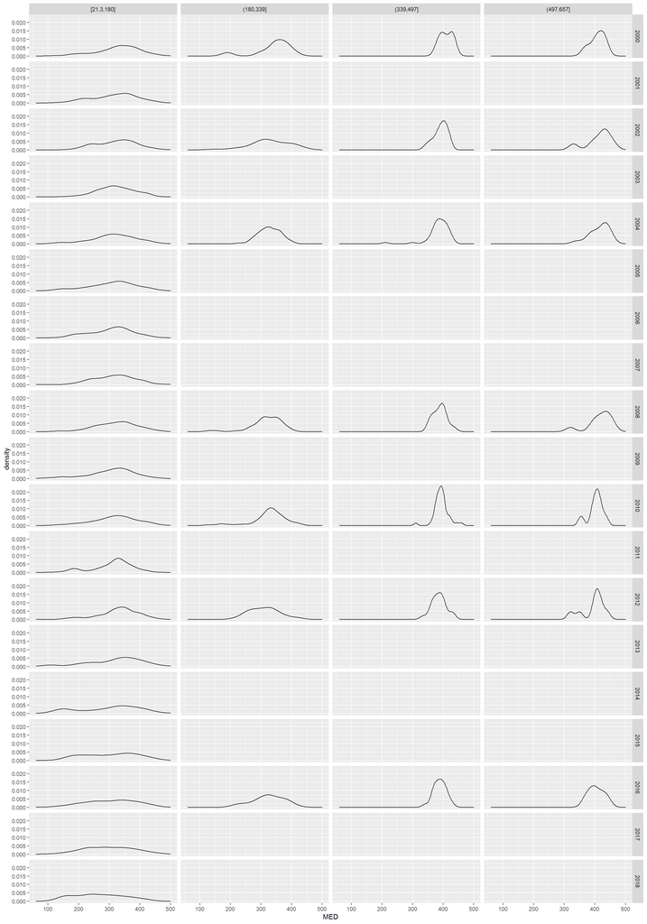

```r
ggplot(plot_dat2) +
  geom_density(aes(x=MED)) +
  facet_grid(YEAR~DEPTH_BINS)
```

Create `get_avg_temp()` function

```r
# make list of the average gear temperature for each year
yearly_avg_temps <- catch %>%
  group_by(YEAR) %>%
  summarise(AVG_TEMP = mean(GEAR_TEMPERATURE, na.rm=TRUE))

get_avg_temp <- function(yr){
  avg <- yearly_avg_temps$AVG_TEMP[which(yearly_avg_temps$YEAR==yr)]
}
```

Moving forward to next `plot_dat` DOESN’T WORK

```r
plot_dat <- len_e %>%
  filter(SPECIES_CODE==10130) %>%
  group_by(STATIONID, YEAR) %>%
  summarise(AVG_TEMP= mean(GEAR_TEMPERATURE, na.rm = TRUE))

plot_dat3 <- inner_join(plot_dat, plot_dat2, by="STATIONID")

#plot_dat4 <- plot_dat3 %>% mutate(YR_AVG_TEMP = get_avg_temp(YEAR.x))
```

Plot `plot_dat3` DOESN’T WORK

```r
# ggplot() +
#   geom_point(data=plot_dat3,aes(x=AVG_TEMP, y=MED)) +
#   facet_grid(data=plot_dat3,YEAR.x~DEPTH_BINS)
```

Setting up data to merge `plot_dat3` and `plot_dat4`

```r
yearly_avg_temps <- catch %>%
  group_by(YEAR) %>%
  summarise(AVG_TEMP = mean(GEAR_TEMPERATURE, na.rm=TRUE))
names(yearly_avg_temps)[2] <- "YEAR_AVG_TEMP"
plot_dat3 <- plot_dat3[,-2]
names(plot_dat3)[3] <- "YEAR"
plot_dat4 <- left_join(plot_dat3, yearly_avg_temps, by="YEAR")
```

Plot 4

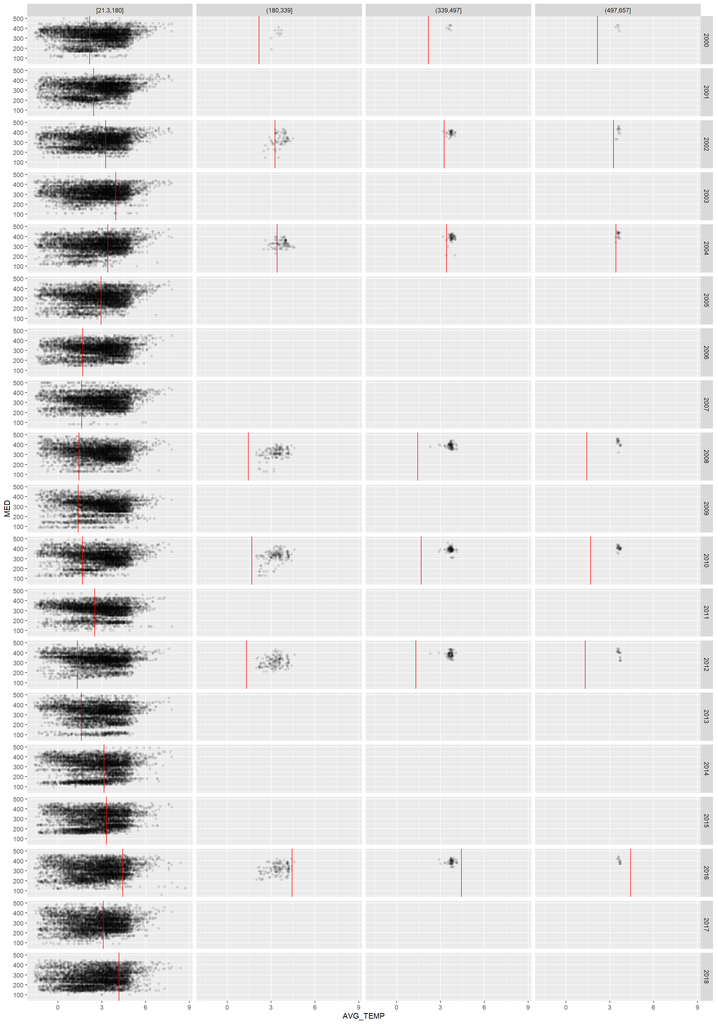

```r
ggplot(plot_dat4) +
  geom_point(aes(x=AVG_TEMP, y=MED), alpha=0.1) +
  facet_grid(YEAR~DEPTH_BINS)+
  geom_vline(aes(xintercept=YEAR_AVG_TEMP), color="red")
```

```r
# ggplot(akp) +
#   geom_point(aes(x=yr_avg_temp, y=med), alpha=0.1) +
#   facet_grid(year~depth_bins, scales="free_x")+
#   geom_vline(aes(xintercept=yr_avg_temp), color="red")
```